# Exercice N°1

## 1. Formalize the problem as a Markov decision process (MDP).

The MDP is defined as follows

- state sapce : The state space consists of all possible agent positions in the 4x4 grid.
  - $S=\{(i,j); i, j ∈ \{0,1, 2,3\} \}$
  - $S= \{(0,0), (0,1), (0,2),(0,3),(1,0),(1,1),(1,2),(1,3),(2,0), (2,1), (2,2), (2,3),(3,0), (3,1), (3,2),(3,3)\}$
- action space :
  - $A=\{Up, Down, Left, Right\} = \{0,1,2,3\}$
  - $A=\{(\Delta i,\Delta j ) ; \Delta i, \Delta j ∈\{-1, 0, 1\} and |\Delta i|+|\Delta j|=1 \}$
  - $A=\{(-1,0), (+1,0), (0,-1), (0,+1)\}$
- Reward function : is function of state and next state
  - R(s, s') = -10, if s=s'
  - R(s,s')=50 if s' is terminate state
  - R(s, s') = -1 otherwise (if s≠s')
- Transition Probability Function:
  - P(s' | s, a) = 1 if:
    - **s**=**s'** and There's a wall in **s** both in the direction of **a** and in the opposite direction of **a**
  - P(s'| s, a) = 0.8 if:
    1. **s'** is adjacent to **s** in the direction of action **a** and There's no wall in **s** in the direction of **a**
    2. **s**=**s'** and There's a wall in **s** in the direction of **a**
  - P(s' | s, a) = 0.2 if:
    1. **s'** is adjacent to **s** in the opposite direction of action **a** and There's no wall in **s** in the opposite direction of **a**
    2. **s**=**s'** and There's a wall in **s** in the opposite direction of **a**
  - P(s' | s, a) = 0 otherwise
- in summary:
  - If the action would result in hitting a wall, the agent stays in the same state.
  - With probability 0.8, the agent moves in the intended direction if there's no wall in the direction of a.
  - With probability 0.2, the agent moves in the opposite direction if there's no wall in the opposite direction of a.
- $γ=0.9$

## 2. What is the objective of penalizing the agent for executing an action that results in hitting a wall.

- To discourage the execution of this type of action.

## 3. What is the objective of penalizing the agent for taking an action that does not lead to the exit cell.

- Encourage the agent to find the shortest path to the exit state

```python
# !pip3 install rich
```

```python
import numpy as np
import matplotlib.pyplot as plt
```

## Plot and Print Function

```python
def plot_maze(maze, start_state, exit_state):
    fig, ax = plt.subplots(figsize=(8, 8))
    rows,cols=maze.shape[:2]
    for i in range(rows):
        for j in range (cols):
            walls=maze[(i,j)]
            if walls[0]: #up
                ax.plot([j, j + 1], [rows - i, rows - i], color='black', linewidth=3)
            if walls[1]: # bottom
                ax.plot([j, j + 1], [rows - i - 1, rows - i - 1], color='black', linewidth=3)
            # Left wall
            if walls[2]: #left
                ax.plot([j, j], [rows - i - 1, rows - i], color='black', linewidth=3)

            if walls[3]: #right
                ax.plot([j + 1, j + 1], [rows - i - 1, rows - i], color='black', linewidth=3)

    for i in range(rows):
        ax.plot([i, i], [0, 4], color="black", linestyle=':', alpha=0.3)  # Vertical grid lines
        ax.plot([0, 4], [i, i], color="black", linestyle=':', alpha=0.3)  # Horizontal grid lines

    ax.text(start_state[1] + 0.5, rows - start_state[0] - 0.5, 'Start', va='center', ha='center', fontsize=25, color='white' ,bbox=dict(facecolor='green', alpha=0.5, pad=10))
    ax.text(exit_state[1] + 0.5, rows - exit_state[0] - 0.5, 'Exit', va='center', ha='center', fontsize=25, color='white', bbox=dict(facecolor='blue', alpha=0.5, pad=10))


    # x, y = start_state[1], rows - start_state[0]
    # ax.arrow(x + 0.5, y , 0, -0.25, fc='green',ec='green',width= 0.05,head_width= 0.2,head_length= 0.2 )


    # x, y = exit_state[1], rows - exit_state[0]
    # ax.arrow(x + 0.5, y - 0.5, 0, -0.25, fc='blue',ec='blue',width= 0.05,head_width= 0.2,head_length= 0.2)

    ax.set_xticks([])
    ax.set_yticks([])

    plt.gca().set_aspect('equal', adjustable='box')
    plt.show()
```

```python
def plot_policy(maze,policy):
    fig, ax = plt.subplots(figsize=(8, 8))
    rows,cols=maze.shape[:2]
    for i in range(rows):
        for j in range (cols):
            walls=maze[(i,j)]
            if walls[0]: #up
                ax.plot([j, j + 1], [rows - i, rows - i], color='black', linewidth=3)
            if walls[1]: # bottom
                ax.plot([j, j + 1], [rows - i - 1, rows - i - 1], color='black', linewidth=3)
            # Left wall
            if walls[2]: #left
                ax.plot([j, j], [rows - i - 1, rows - i], color='black', linewidth=3)

            if walls[3]: #right
                ax.plot([j + 1, j + 1], [rows - i - 1, rows - i], color='black', linewidth=3)


    # Plot policy
    if policy is not None:
        for i in range(rows):
            for j in range(cols):
                center_y, center_x = rows - i - 0.5, j + 0.5
                ax.plot(center_y, center_x, 'o',c='blue')

                if type(policy[(i,j)]) is np.float64:
                    dx, dy = 0, 0
                    if policy[(i,j)] == 0:  # up
                        dy = 0.25
                    elif policy[(i,j)] == 1:  # down
                        dy = -0.25
                    elif policy[(i,j)] == 2:  # left
                        dx = -0.25
                    elif policy[(i,j)] == 3:  # right
                        dx = 0.25

                    ax.arrow(center_x, center_y, dx* 1.3, dy*1.3,
                            fc='red', ec='red',
                            width=0.03,
                            head_width=0.1 ,
                            head_length=0.1 ,
                            alpha=0.7)

                else:
                    for action, prob in enumerate(policy[i, j]):
                        if prob > 0:
                            dx, dy = 0, 0
                            if action == 0:  # up
                                dy = 0.25
                            elif action == 1:  # down
                                dy = -0.25
                            elif action == 2:  # left
                                dx = -0.25
                            elif action == 3:  # right
                                dx = 0.25

                            ax.arrow(center_x, center_y, dx* (prob+0.3), dy*(prob+0.3),
                                    fc='red', ec='red',
                                    width=0.03,
                                    head_width=0.1 ,
                                    head_length=0.1 ,
                                    alpha=0.7)

    ax.set_xticks([])
    ax.set_yticks([])

    plt.gca().set_aspect('equal', adjustable='box')
    plt.show()
```

```python
def plot_value_function(v):
    rows,cols=v.shape[:2]
    plt.imshow(v, cmap='Greys')
    for i in range(rows):
        for j in range (cols):
            plt.text(j, i, f'{round(v[i, j],2)}', ha='center', va='center', color='r', fontsize=15)
    plt.xticks([]) # Hide the x-axis values
    plt.yticks([]) # Hide the y-axis values
    plt.show()
```

```python
from rich.console import Console
from rich.tree import Tree
def print_transition(T):
    console = Console()
    def build_tree(data, parent_tree):
        for i, row in enumerate(data):
            row_tree = parent_tree.add(f"Row {i}")
            for j, col in enumerate(row):
                col_tree = row_tree.add(f"Col {j}")
                for k,action in enumerate(col):
                    action_tree = col_tree.add(f"action {k}")
                    for k, v in action.items():
                        action_tree.add(f"[cyan]{k}[/cyan]: [magenta]{v}[/magenta]")

    # Create a root tree
    root_tree = Tree("NumPy Array Structure")
    build_tree(T.tolist(), root_tree)

    # Print the tree to the console
    console.print(root_tree)
```

## Initialization

```python
#global variables
max_steps=16
start_state=(0,0)
exit_state=(3,3)
gamma=0.9
theta=10**(-10)
```

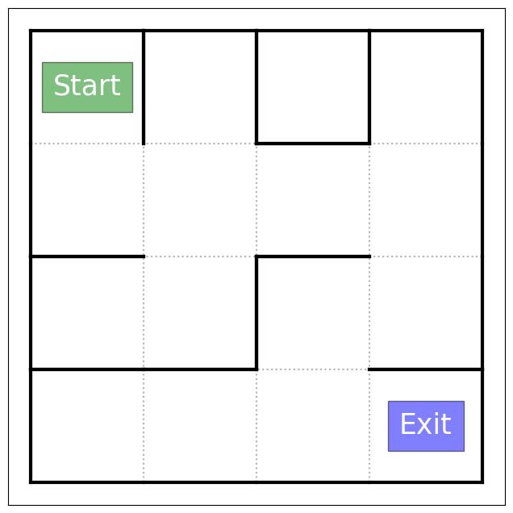

```python
#wall = [up, down, left, right] = [0,1,2,3]
# maze [cell][wall]
maze = np.array(
    [
        [[1, 0, 1, 1], [1, 0, 1, 1], [1, 1, 1, 1], [1, 0, 1, 1]],
        [[0, 1, 1, 0], [0, 0, 0, 0], [1, 1, 0, 0], [0, 0, 0, 1]],
        [[1, 1, 1, 0], [0, 1, 0, 1], [1, 0, 1, 0], [0, 1, 0, 1]],
        [[1, 1, 1, 0], [1, 1, 0, 0], [0, 1, 0, 0], [1, 1, 0, 1]],
    ]
)
plot_maze(maze, start_state,exit_state)
```

```python
action_space=[(-1,0), (1,0), (0,-1), (0,1)]

def get_nextState(state:tuple, action_num:int):

    # Get the wall configuration for the current state
    walls = maze[state]
    # Check if there's a wall in the direction of the chosen action
    if walls[action_num]:
        return state  # If there's a wall, stay in the current state
    else: # Calculate the next state
        action=action_space[action_num]
        nxtState=(state[0]+action[0],state[1]+action[1])
        return nxtState

    # # Check if the next state is within the maze boundaries
    # if (nxtState[0]>=0 and nxtState[0]<=3 and nxtState[1]>=0 and nxtState[1]<=3):
    #     return nxtState # Return the new state if it's valid
    # else:
    #     return state     # Stay in the current state if the next state is out of bounds

get_nextState((0,0),3)
```

```
(0, 0)
```

```python
# Define the opposite action/direction for each action
opposite_action = [1, 0, 3, 2]

def transition_probabilities():
    rows,cols=maze.shape[:2]
    nb_action=len(action_space)
    T=np.empty((rows,cols,nb_action), dtype=object)

    for i in range (rows):
        for j in range (cols):
            for action in range(nb_action):
                    intended_state=get_nextState((i,j),action)
                    oposite_state=get_nextState((i,j),opposite_action[action])
                    if intended_state== oposite_state:
                        T[i][j][action]={intended_state:1}
                    else:
                        T[i][j][action]={
                             intended_state:0.8, # With 0.8 probability, take the intended action
                             oposite_state:0.2  # With 0.2 probability, take the opposite action
                            }
    return T

T=transition_probabilities()
print_transition(T)
```

```
NumPy Array Structure
├── Row 0
│   ├── Col 0
│   │   ├── action 0
│   │   │   ├── (0, 0): 0.8
│   │   │   └── (1, 0): 0.2
│   │   ├── action 1
│   │   │   ├── (1, 0): 0.8
│   │   │   └── (0, 0): 0.2
│   │   ├── action 2
│   │   │   └── (0, 0): 1
│   │   └── action 3
│   │       └── (0, 0): 1
│   ├── Col 1
│   │   ├── action 0
│   │   │   ├── (0, 1): 0.8
│   │   │   └── (1, 1): 0.2
│   │   ├── action 1
│   │   │   ├── (1, 1): 0.8
│   │   │   └── (0, 1): 0.2
│   │   ├── action 2
│   │   │   └── (0, 1): 1
│   │   └── action 3
│   │       └── (0, 1): 1
│   ├── Col 2
│   │   ├── action 0
│   │   │   └── (0, 2): 1
│   │   ├── action 1
│   │   │   └── (0, 2): 1
│   │   ├── action 2
│   │   │   └── (0, 2): 1
│   │   └── action 3
│   │       └── (0, 2): 1
│   └── Col 3
│       ├── action 0
│       │   ├── (0, 3): 0.8
│       │   └── (1, 3): 0.2
│       ├── action 1
│       │   ├── (1, 3): 0.8
│       │   └── (0, 3): 0.2
```

[output cut: 138 more lines]

```
    │   │   └── (3, 3): 0.2
    │   └── action 3
    │       ├── (3, 3): 0.8
    │       └── (3, 1): 0.2
    └── Col 3
        ├── action 0
        │   └── (3, 3): 1
        ├── action 1
        │   └── (3, 3): 1
        ├── action 2
        │   ├── (3, 2): 0.8
        │   └── (3, 3): 0.2
        └── action 3
            ├── (3, 3): 0.8
            └── (3, 2): 0.2
```

```python
def reward(state, nxtState):
    if state==nxtState:
        return -10
    elif nxtState==exit_state:
        return 50
    else:
        return -1

reward((0,0),(3,2))
# reward((0,0),(0,0))
# reward((0,0),(1,0))
```

```
-1
```

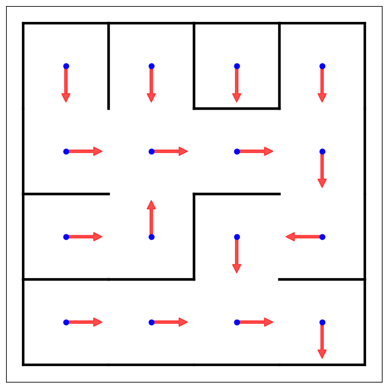

```python
policy1=np.array([
    [[0., 1., 0., 0.], [0., 1., 0., 0.], [0., 1., 0., 0.], [0., 1., 0., 0.]],
    [[0., 0., 0., 1.], [0., 0., 0., 1.], [0., 0., 0., 1.], [0., 1., 0., 0.]],
    [[0., 0., 0., 1.], [1., 0., 0., 0.], [0., 1., 0., 0.], [0., 0., 1., 0.]],
    [[0., 0., 0., 1.], [0., 0., 0., 1.], [0., 0., 0., 1.], [0., 1., 0., 0.]],
    ])
plot_policy(maze,policy1)
```

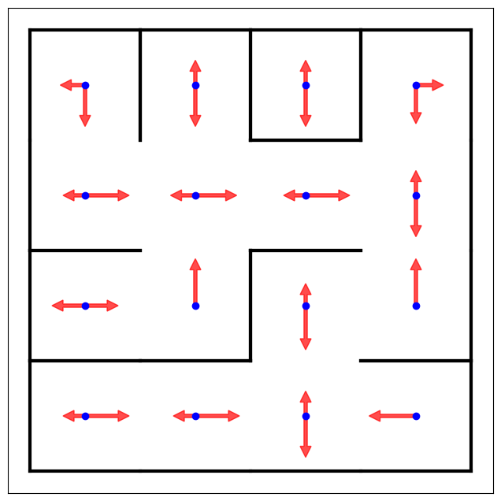

```python
policy2=np.array([
    [[0., 0.8, 0.2, 0.], [0.2, 0.8, 0., 0.], [0.2, 0.8, 0., 0.], [0., 0.7, 0., 0.3]],
    [[0., 0., 0.1, 0.9], [0., 0., 0.2, 0.8], [0., 0., 0.1, 0.9], [0.2, 0.8, 0., 0.]],
    [[0., 0., 0.5, 0.5], [1., 0., 0., 0.], [0.1, 0.9, 0., 0.],  [1., 0., 0., 0.]],
    [[0., 0., 0.1, 0.9],  [0., 0., 0.1, 0.9], [0.2, 0.8, 0., 0.], [0., 0., 1., 0.]],
    ])
plot_policy(maze,policy2)
```

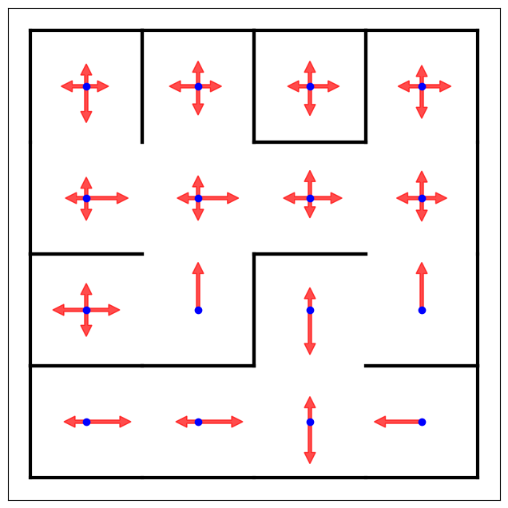

```python
policy3=np.array([
    [[0.1, 0.6, 0.2, 0.1], [0.2, 0.33, 0.33, 0.14], [0.2, 0.35, 0.1, 0.35], [0.05, 0.45, 0.15, 0.35]],
    [[0.05, 0.1, 0.05, 0.8], [0.1, 0.1, 0.05, 0.75], [0.29, 0.01, 0.25, 0.45], [0.27, 0.13, 0.2, 0.2]],
    [[0.25, 0.25, 0.5, 0.5], [1., 0., 0., 0.], [0.1, 0.9, 0., 0.],  [1., 0., 0., 0.]],
    [[0., 0., 0.1, 0.9],  [0., 0., 0.1, 0.9], [0.2, 0.8, 0., 0.], [0., 0., 1., 0.]],
    ])
plot_policy(maze,policy3)
```

## 4. a. Policy evaluation (computing state-value function)

[figure not shown]

- use bellman equation as update rule $$V_π^{k+1}(s)= \sum_a π(a|s) \sum_{s',r} p(s',r|s,a)[r+\gamma V_π^k(s')] $$

```python
def policy_evaluation(policy):
    rows,cols=maze.shape[:2]
    valueFunction=np.zeros((rows,cols))
    itr=0
    while True:
        valueFunctionPrev=valueFunction.copy()
        for i in range(rows):
            for j in range(cols):
                valueFunction[(i,j)] =np.sum([
                        policy[(i,j)][a] *np.sum([
                            prob*(reward((i,j),nxtState)+gamma*valueFunctionPrev[nxtState])
                                for  nxtState, prob in T[(i,j)][a].items() ])
                        for a in range(len(action_space))
                    ])

        if (np.max(np.abs(valueFunctionPrev-valueFunction))<theta):
            print(np.max(np.abs(valueFunctionPrev-valueFunction)))
            print("nb iteration=",itr)
            break
        itr+=1
    return valueFunction
```

[output not shown]

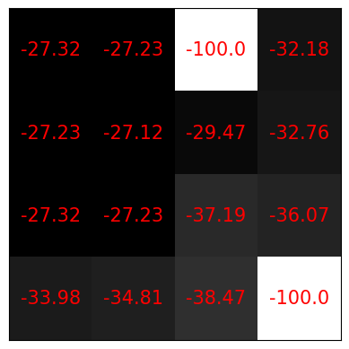

```python
# policy1 evaluation
value1=policy_evaluation(policy1)
plot_value_function(value1)
```

#### PS

We see that the value function in (i-1) iteration and the value function in (i) iteration are the same because we have rounded the value to two decimal places.

```
9.386269539390923e-11
nb iteration= 241
```

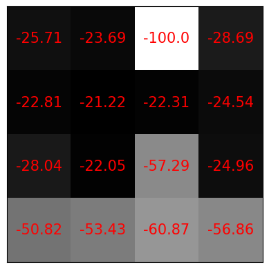

```python
# policy2 evaluation
value2=policy_evaluation(policy2)
plot_value_function(value2)
```

```
9.64917035162216e-11
nb iteration= 256
```

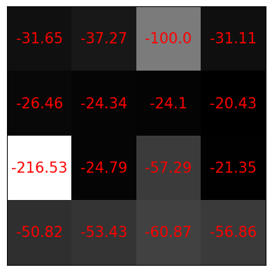

```python
# policy3 evaluation
value3=policy_evaluation(policy3)
plot_value_function(value3)
```

## 4. b. Policy improvement

- find a better policy π' than π , using the computed value-function

$$π'(s)=argmax_aq_π(a|s)$$ $$q_π(a|s)= \sum_{s',r} p(s',r|s,a)[r+\gamma V(s')] $$ $$π'(s)=argmax_a \sum_{s',r} p(s',r|s,a)[r+\gamma V(s')] $$

```python
def policy_improvement(v):
    #compute q(a|s])
    rows,cols=maze.shape[:2]
    q=np.zeros((rows,cols,len(action_space)))
    for i in range(rows):
        for j in range(cols):
            for a in range(len(action_space)):
                # for sN in range(state_space):
                #     q[s][a]+=transition[sN][a][s]*(rewards[sN][a][s]+gamma*v[sN])
                q[i][j][a]=np.sum([
                    prob*(reward((i,j),nxtState)+gamma*v[nxtState])
                    for  nxtState, prob in T[(i,j)][a].items()
                ])


    # get a policy by acting greedily
    policy=np.zeros((rows,cols,len(action_space)))
    for i in range(rows):
        for j in range(cols):
            max = q[(i,j)].max()
            argmax = np.where(q[(i,j)] == max)
            for arg in argmax[0]:
                policy[(i,j)][arg]=1/len(argmax[0])
    return policy
```

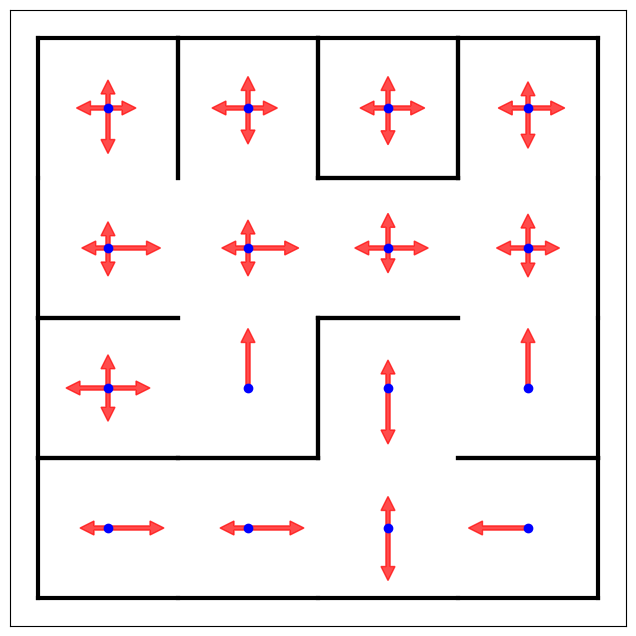

```python
plot_policy(maze,policy3)
```

```
9.386269539390923e-11
nb iteration= 241
```

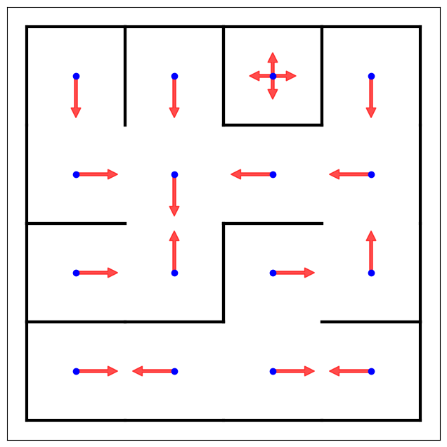

```python
value_policy2=policy_evaluation(policy2)
new_policy2=policy_improvement(value_policy2)

plot_policy(maze,new_policy2)
```

## 5. Policy iteration

[figure not shown]

```python
def policy_iteration():
    rows,cols=maze.shape[:2]
    policy=np.full((rows,cols,len(action_space)),1/len(action_space))
    itr=1
    while True:
        value=policy_evaluation(policy)
        oldpolicy=policy.copy()
        policy=policy_improvement(value)
        if(oldpolicy.all()==policy.all()):
            print('iteration=',itr)
            break
        itr+=1
    return(policy, value)
```

```
9.384848453919403e-11
nb iteration= 241
9.740119821799453e-11
nb iteration= 245
iteration= 2
```

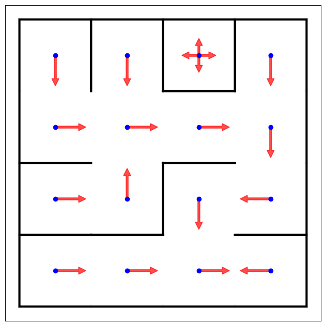

```python
optimalPolicy,optimalValue=policy_iteration()
plot_policy(maze,optimalPolicy)
```

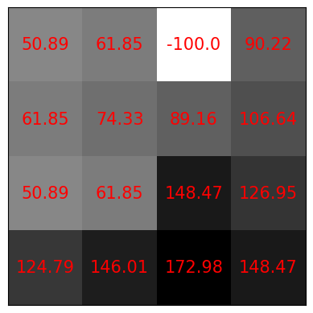

```python
plot_value_function(optimalValue)
```

## 6. Value iteration

[figure not shown]

- Use the bellman optimality equation as update rule $$V(s)= \max_a \sum_{s',r} p(s',r|s,a)[r+\gamma V(s')] $$

```python
def value_iteration():
    rows,cols=maze.shape[:2]
    value=np.zeros((rows,cols))
    itr=0
    while True:
        valueOld=value.copy()
        for i in range(rows):
            for j in range (cols):
                value_action=np.zeros(len(action_space))
                for a in range(len(action_space)):
                    value_action[a]= np.sum([
                        prob*(reward((i,j),nxtState)+gamma*valueOld[nxtState])
                        for  nxtState, prob in T[(i,j)][a].items() ])

                value[(i,j)]=value_action.max()
        if (np.max(np.abs(valueOld-value))<theta):
            print("nb iteration=",itr)
            break
        itr+=1


    policy=np.zeros((rows,cols))
    for i in range(rows):
        for j in range (cols):
            policy[(i,j)]=np.argmax([
                    np.sum([
                       prob*(reward((i,j),nxtState)+gamma*value[nxtState])
                        for  nxtState, prob in T[(i,j)][a].items() ])

                    for a in range(len(action_space))
                ])
    return (policy,value)
```

```python
optimalpolicyVI, optimalValueVI=value_iteration()
```

```
nb iteration= 245
```

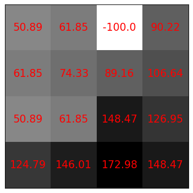

```python
plot_value_function(optimalValueVI)
```

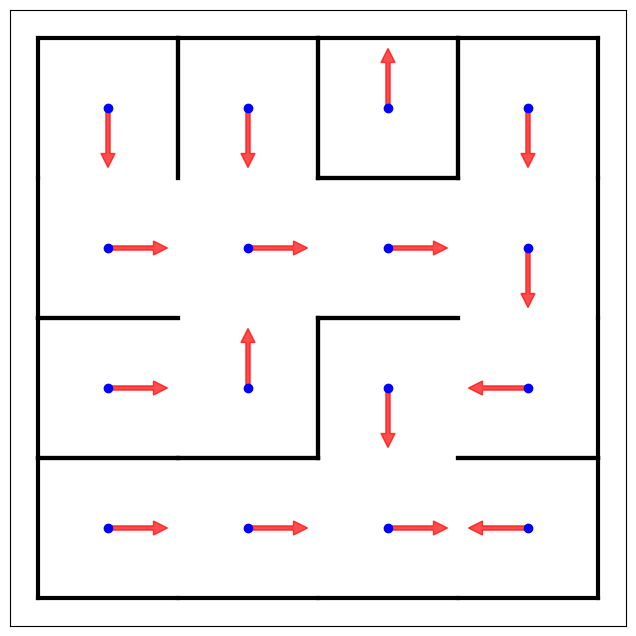

```python
plot_policy(maze,optimalpolicyVI)
```

## Test the work of the learned policy

```python
import random
# Testing Deterministic Policy
def test_policy(policy):
    state=start_state
    i=1
    total_reward=0
    while True:
        action=int(policy[state])
        # print(action)
        pro = T[state][action]
        nxtState=random.choices(list(pro.keys()), weights=list(pro.values()))[0]
        rwd=reward(state, nxtState)
        total_reward+=rwd
        state=nxtState
        i+=1
        if (state==exit_state or i>max_steps):
            break
    if state==exit_state:
        print("success, total_reward=", total_reward, "steps=",i)
    else:
        print("fail,total_reward=", total_reward, "steps=",i)


test_policy(optimalpolicyVI)
```

```
success, total_reward= 9 steps= 16
```